# Relationship between Race and Unemployment rate in USA

Aditya Kumar Singh

July 12, 2016

## Introduction

**Q : DOES RACE INFLUENCES THE UNEMPLOEMENT RATE IN USA ??** **Q : WHY DO I CARE ABOUT THE QUESTION?** *I care about the question because it is important to know whether unemployment rate is effeced by races or not ? And if there is some connection so necessary steps should be taken to nullify this unemployment rate difference between various races*

## Data

**General Social Survey (GSS)**: A sociological survey used to collect data on demographic characteristics and attitudes of residents of the United States. The codebook below lists all variables, the values they take, and the survey questions associated with them. There are a total of 57,061 cases and 114 variables in this dataset. Note that this is a cumulative data file for surveys conducted between 1972 - 2012 and that not all respondents answered all questions in all years.

# Load the Data

```r
load(url("http://bit.ly/dasi_gss_data"))
```

# Loading packages

```r
library(plyr)
library(dplyr)
```

```r
library(ggplot2)
```

# Creating required subset

```r
gss35<- subset(gss,gss$year >="1990")
```

Now in order to address our project question we create a subset from the above created subset

```r
needed <- gss35 %>%
  select(race,unemp )
needed <- na.omit(needed)
```

# Summary statistics

```r
summary(needed)
```

```
##     race       unemp
##  White:14622   Yes: 5993
##  Black: 2519   No :12472
##  Other: 1324
```

## Exploratory Analysis

In order to visualise the distribution of unemployed(Yes) and employed(No) over different races we run following code

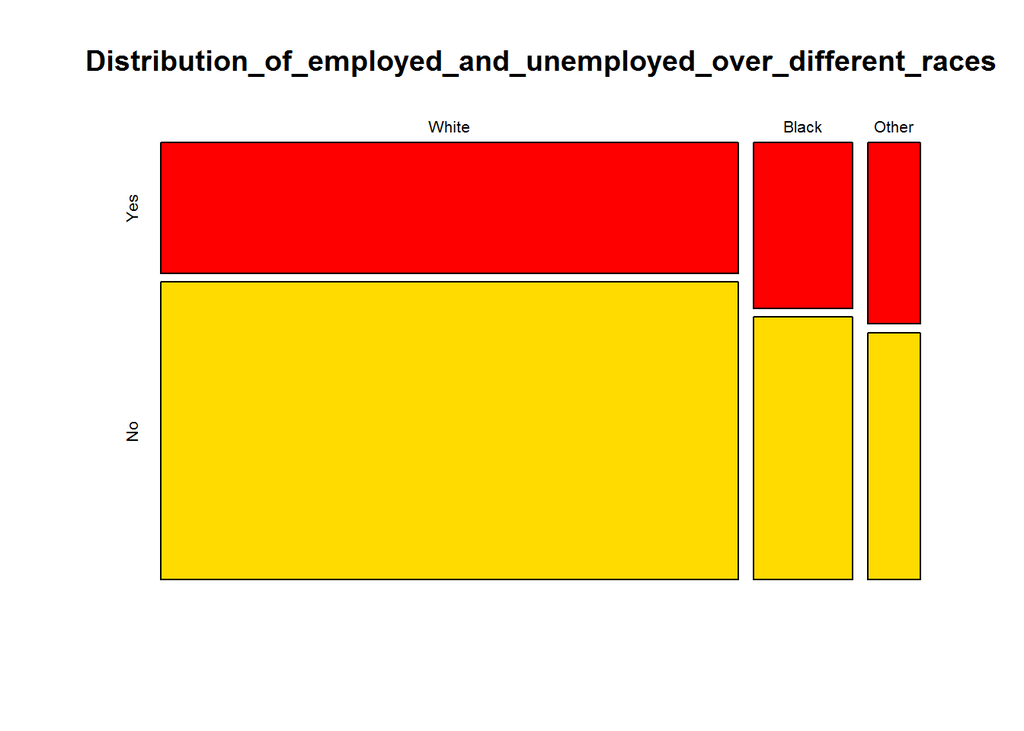

```r
mosaicplot(table(needed$race,needed$unemp  ) , col = rainbow(7), main =  "Distribution_of_employed_and_unemployed_over_different_races")
```

Let get a deeper look in the **unemploment rate (proportion of people unemployed) in each race**

```r
 y <- needed %>%
  mutate(binaryform = ifelse( unemp == "Yes" , 1 , 0))

x <- y %>%
  group_by(race) %>%
  summarise(proportion =  sum(binaryform)/n()  )
 class(x)
```

```
## [1] "tbl_df"     "tbl"        "data.frame"
```

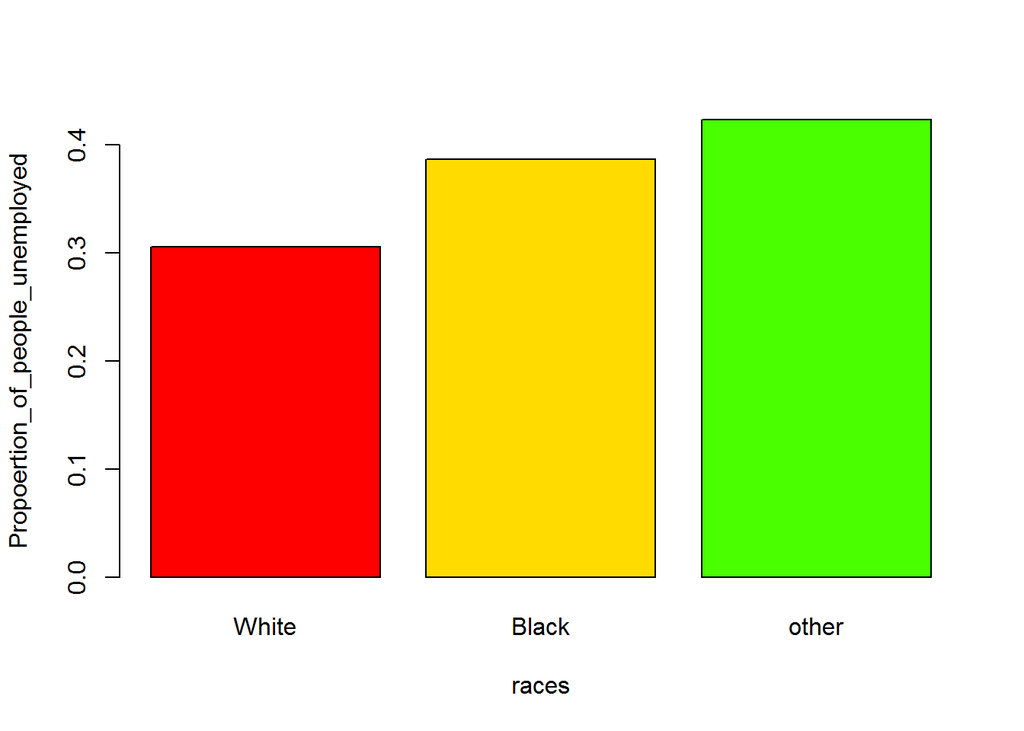

```r
 x<- as.data.frame(x)

barplot(x$proportion , names.arg = c("White" , "Black" , "other") ,col = rainbow(7) , ylab = "Propoertion_of_people_unemployed" , xlab = "races" )
```

In plot we can see the proportion of unemployed people in different races differes

## Inference

**AIM:**Our aim is to find out whether there is a relationship between races and unemployment rate or not. For this we will take help of hypothesis testing** Our null hypothesis** H_O = There is no relationship between races and unemployment rate in USA **Our alternative hypothesis** H_A = There is some relationship between races and unemployment rate in USA

Here we gonna take help of Chi-Square test of independence to check the hypothesis because in one category we have more than two levels

```r
table(needed$unemp ,needed$race)
```

```
##
##       White Black Other
##   Yes  4460   973   560
##   No  10162  1546   764
```

# Condition check for the test

Conditions for Chi-Squared test ofIndependence: **1. Independence:** GSS data consist in a random sample from less than 10% of the population and so they could be considered independent and each case is contributin to only one cell in the table

**2.Sample Size:** We can see from the table above, each particular scenerio has more than 5 cases

# Performing Chi-Square test of Independence

```r
chisq.test(table(needed$unemp ,needed$race))
```

```
##
##  Pearson's Chi-squared test
##
## data:  table(needed$unemp, needed$race)
## X-squared = 127.7, df = 2, p-value < 2.2e-16
```

## Conclusion

The **P-value is < 2.2e-16** , which is a very small value , from this we can reject the null hypothesis which say there is no relationship between races and unemployment rate in USA in favour of alternate hypothesis. This an alarming condition and necessary steps should be taken to overcome such difference between unemployment rate over races.

## Appendix

```r
names(gss35)
```

```
##   [1] "caseid"   "year"     "age"      "sex"      "race"     "hispanic"
##   [7] "uscitzn"  "educ"     "paeduc"   "maeduc"   "speduc"   "degree"
##  [13] "vetyears" "sei"      "wrkstat"  "wrkslf"   "marital"  "spwrksta"
##  [19] "sibs"     "childs"   "agekdbrn" "incom16"  "born"     "parborn"
##  [25] "granborn" "income06" "coninc"   "region"   "partyid"  "polviews"
##  [31] "relig"    "attend"   "natspac"  "natenvir" "natheal"  "natcity"
##  [37] "natcrime" "natdrug"  "nateduc"  "natrace"  "natarms"  "nataid"
##  [43] "natfare"  "natroad"  "natsoc"   "natmass"  "natpark"  "confinan"
##  [49] "conbus"   "conclerg" "coneduc"  "confed"   "conlabor" "conpress"
##  [55] "conmedic" "contv"    "conjudge" "consci"   "conlegis" "conarmy"
##  [61] "joblose"  "jobfind"  "satjob"   "richwork" "jobinc"   "jobsec"
##  [67] "jobhour"  "jobpromo" "jobmeans" "class"    "rank"     "satfin"
##  [73] "finalter" "finrela"  "unemp"    "govaid"   "getaid"   "union"
##  [79] "getahead" "parsol"   "kidssol"  "abdefect" "abnomore" "abhlth"
##  [85] "abpoor"   "abrape"   "absingle" "abany"    "pillok"   "sexeduc"
##  [91] "divlaw"   "premarsx" "teensex"  "xmarsex"  "homosex"  "suicide1"
##  [97] "suicide2" "suicide3" "suicide4" "fear"     "owngun"   "pistol"
## [103] "shotgun"  "rifle"    "news"     "tvhours"  "racdif1"  "racdif2"
## [109] "racdif3"  "racdif4"  "helppoor" "helpnot"  "helpsick" "helpblk"
```

```r
head(gss35,5)
```

```
##       caseid year age    sex  race hispanic uscitzn educ paeduc maeduc
## 24894  24894 1990  65 Female White     <NA>    <NA>   16      2      0
## 24895  24895 1990  42   Male White     <NA>    <NA>   20     12     12
## 24896  24896 1990  25   Male White     <NA>    <NA>   16     18     16
## 24897  24897 1990  39 Female White     <NA>    <NA>   14     NA     12
## 24898  24898 1990  55   Male Black     <NA>    <NA>    8      8      8
##       speduc         degree     vetyears  sei          wrkstat
## 24894     NA       Bachelor         None 71.6 Working Fulltime
## 24895     NA       Graduate         None 53.3 Working Fulltime
## 24896     NA       Bachelor         None 63.5 Working Fulltime
## 24897     NA    High School         None 50.5 Working Fulltime
## 24898     NA Lt High School 2 To 4 Years 28.6          Retired
##              wrkslf       marital spwrksta sibs childs agekdbrn
## 24894  Someone Else Never Married     <NA>    2      0       NA
## 24895  Someone Else Never Married     <NA>    1      0       NA
```

[output cut: 105 more lines]

# for my subset

```r
names(needed)
```

```
## [1] "race"  "unemp"
```

```r
head(needed,50)
```

```
##        race unemp
## 24894 White    No
## 24895 White   Yes
## 24898 Black    No
## 24900 Black    No
## 24903 White    No
## 24905 White    No
## 24906 White   Yes
## 24907 White    No
## 24909 Black    No
## 24910 White    No
## 24913 Black    No
## 24914 Black    No
## 24916 Other   Yes
## 24917 Other    No
```

[output cut: 36 more lines]